# ABAR: Chapter 3

Data visualization is a critical tool in the data analysis process. Visualization tasks can range from generating fundamental distribution plots to understanding the interplay of complex influential variables in machine learning algorithms. In this chapter we focus on the use of visualization for initial *data exploration*.

Regardless, visual data exploration is about investigating the characteristics of your data set. To do this, we typically create numerous plots in an interactive fashion. This chapter will show you how to create plots that answer some of the fundamental questions we typically have of our data.

```r
library(tidyverse)
library(caret)
```

```r
(ames <- AmesHousing::make_ames())
```

| MS_SubClass | MS_Zoning | Lot_Frontage | Lot_Area | Street | Alley | Lot_Shape | Land_Contour | Utilities | Lot_Config | Land_Slope | Neighborhood | Condition_1 | Condition_2 | Bldg_Type | House_Style | Overall_Qual | Overall_Cond | Year_Built | Year_Remod_Add | Roof_Style | Roof_Matl | Exterior_1st | Exterior_2nd | Mas_Vnr_Type | Mas_Vnr_Area | Exter_Qual | Exter_Cond | Foundation | Bsmt_Qual | … |
| --- | --- | --- | --- | --- | --- | --- | --- | --- | --- | --- | --- | --- | --- | --- | --- | --- | --- | --- | --- | --- | --- | --- | --- | --- | --- | --- | --- | --- | --- | --- |
| One_Story_1946_and_Newer_All_Styles | Residential_Low_Density | 141 | 31770 | Pave | No_Alley_Access | Slightly_Irregular | Lvl | AllPub | Corner | Gtl | North_Ames | Norm | Norm | OneFam | One_Story | Above_Average | Average | 1960 | 1960 | Hip | CompShg | BrkFace | Plywood | Stone | 112 | Typical | Typical | CBlock | Typical | … |
| One_Story_1946_and_Newer_All_Styles | Residential_High_Density | 80 | 11622 | Pave | No_Alley_Access | Regular | Lvl | AllPub | Inside | Gtl | North_Ames | Feedr | Norm | OneFam | One_Story | Average | Above_Average | 1961 | 1961 | Gable | CompShg | VinylSd | VinylSd | None | 0 | Typical | Typical | CBlock | Typical | … |
| One_Story_1946_and_Newer_All_Styles | Residential_Low_Density | 81 | 14267 | Pave | No_Alley_Access | Slightly_Irregular | Lvl | AllPub | Corner | Gtl | North_Ames | Norm | Norm | OneFam | One_Story | Above_Average | Above_Average | 1958 | 1958 | Hip | CompShg | Wd Sdng | Wd Sdng | BrkFace | 108 | Typical | Typical | CBlock | Typical | … |
| One_Story_1946_and_Newer_All_Styles | Residential_Low_Density | 93 | 11160 | Pave | No_Alley_Access | Regular | Lvl | AllPub | Corner | Gtl | North_Ames | Norm | Norm | OneFam | One_Story | Good | Average | 1968 | 1968 | Hip | CompShg | BrkFace | BrkFace | None | 0 | Good | Typical | CBlock | Typical | … |
| Two_Story_1946_and_Newer | Residential_Low_Density | 74 | 13830 | Pave | No_Alley_Access | Slightly_Irregular | Lvl | AllPub | Inside | Gtl | Gilbert | Norm | Norm | OneFam | Two_Story | Average | Average | 1997 | 1998 | Gable | CompShg | VinylSd | VinylSd | None | 0 | Typical | Typical | PConc | Good | … |
| Two_Story_1946_and_Newer | Residential_Low_Density | 78 | 9978 | Pave | No_Alley_Access | Slightly_Irregular | Lvl | AllPub | Inside | Gtl | Gilbert | Norm | Norm | OneFam | Two_Story | Above_Average | Above_Average | 1998 | 1998 | Gable | CompShg | VinylSd | VinylSd | BrkFace | 20 | Typical | Typical | PConc | Typical | … |
| One_Story_PUD_1946_and_Newer | Residential_Low_Density | 41 | 4920 | Pave | No_Alley_Access | Regular | Lvl | AllPub | Inside | Gtl | Stone_Brook | Norm | Norm | TwnhsE | One_Story | Very_Good | Average | 2001 | 2001 | Gable | CompShg | CemntBd | CmentBd | None | 0 | Good | Typical | PConc | Good | … |
| One_Story_PUD_1946_and_Newer | Residential_Low_Density | 43 | 5005 | Pave | No_Alley_Access | Slightly_Irregular | HLS | AllPub | Inside | Gtl | Stone_Brook | Norm | Norm | TwnhsE | One_Story | Very_Good | Average | 1992 | 1992 | Gable | CompShg | HdBoard | HdBoard | None | 0 | Good | Typical | PConc | Good | … |
| One_Story_PUD_1946_and_Newer | Residential_Low_Density | 39 | 5389 | Pave | No_Alley_Access | Slightly_Irregular | Lvl | AllPub | Inside | Gtl | Stone_Brook | Norm | Norm | TwnhsE | One_Story | Very_Good | Average | 1995 | 1996 | Gable | CompShg | CemntBd | CmentBd | None | 0 | Good | Typical | PConc | Good | … |
| Two_Story_1946_and_Newer | Residential_Low_Density | 60 | 7500 | Pave | No_Alley_Access | Regular | Lvl | AllPub | Inside | Gtl | Gilbert | Norm | Norm | OneFam | Two_Story | Good | Average | 1999 | 1999 | Gable | CompShg | VinylSd | VinylSd | None | 0 | Typical | Typical | PConc | Typical | … |

[output cut: 990 more lines]

# Visualizing Continuous Variables

A variable is continuous if it can take any of an infinite set of ordered values. There are several different plots that can effectively communicate the different features of continuous variables. Features we are generally interested in include:

- Measures of location
- Measures of spread
- Asymmetry
- Outliers
- Gaps

Histograms are often overlooked, yet they are a very efficient means for communicating these features of continuous variables. Formulated by Karl Pearson, histograms display numeric values on the x-axis where the continuous variable is broken into intervals (aka bins) and the the y-axis represents the frequency of observations that fall into that bin. Histograms quickly signal what the most common observations are for the variable being assessed (the higher the bar the more frequent those values are observed in the data); they also signal the shape (spread and symmetr) of your data by illustrating if the observed values cluster towards one end or the other of the distribution.

To get a quick sense of how sales prices are distributed across the 2,930 properties in the `ames` data we can generate a simple histogram by applying ggplot’s `geom_histogram` function[^1]. This histogram tells us several important features about our variable:

- Measures of location: We can see the most common `Sale_Price` is around the low $100K.
- Measures of spread: Our `Sale_Price` ranges from near zero to over $700K.
- Asymmetry: `Sale_Price` is skewed right (a common issue with financial data). Depending on the analytic technique we may want to apply later on this suggests we will likely need to transform this variable.
- Outliers: It appears that there are some large values far from the other `Sale_Price` values. Whether these are outliers in the mathematical sense or outliers to be concerned about is another issue but for now we at least know they exist.
- Gaps: We see a gap exists between `Sale_Price` values around $650K and $700K+.

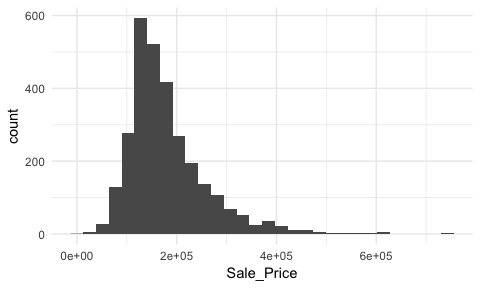

```r
ggplot(ames, aes(Sale_Price)) +
  geom_histogram()
```

By default, `geom_histogram()` will divide your data into 30 equal bins or intervals. Since sales prices range from $12,789 - $755,000, dividing this range into 30 equal bins means the bin width is $24,740. So the first bar will represent the frequency of `Sale_Price` values that range from about $12,500 to about $37,500[^2], the second bar represents the income range from about 37,500 to 62,300, and so on.

However, we can control this parameter by changing the bin width argument in `geom_histogram`. By changing the bin width when doing exploratory analysis you can get a more detailed picture of the relative densities of the distribution. For instance, in the default histogram there was a bin of $136,000 - $161,000 values that had the highest frequency but as the histograms that follow show, we can gather more information as we adjust the binning.

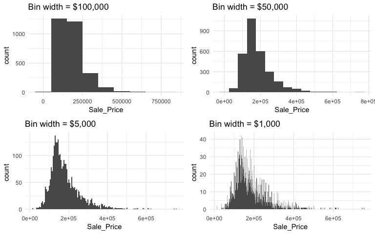

```r
p1 <- ggplot(ames, aes(Sale_Price)) +
  geom_histogram(binwidth = 100000) +
  ggtitle("Bin width = $100,000")
p2 <- ggplot(ames, aes(Sale_Price)) +
  geom_histogram(binwidth = 50000) +
  ggtitle("Bin width = $50,000")
p3 <- ggplot(ames, aes(Sale_Price)) +
  geom_histogram(binwidth = 5000) +
  ggtitle("Bin width = $5,000")
p4 <- ggplot(ames, aes(Sale_Price)) +
  geom_histogram(binwidth = 1000) +
  ggtitle("Bin width = $1,000")
gridExtra::grid.arrange(p1, p2, p3, p4, ncol = 2)
```

Overall, the histograms consistently show the most common income level to be right around $130,000. We can also find the most frequent bin by combining `ggplot2::cut_width` (`ggplot2::cut_interval` and `ggplot2::cut_number` are additional options) with `dplyr::count`. We see that the most frequent bin when using increments of $5,000 is $128,000 - $132,000.

```r
ames %>%
  count(cut_width(Sale_Price, width = 5000)) %>%
  arrange(desc(n))
```

| cut_width(Sale_Price, width = 5000) | n |
| --- | --- |
| (1.28e+05,1.32e+05] | 137 |
| (1.42e+05,1.48e+05] | 130 |
| (1.32e+05,1.38e+05] | 125 |
| (1.38e+05,1.42e+05] | 125 |
| (1.22e+05,1.28e+05] | 118 |
| (1.52e+05,1.58e+05] | 103 |
| (1.48e+05,1.52e+05] | 101 |
| (1.18e+05,1.22e+05] | 99 |
| (1.58e+05,1.62e+05] | 92 |
| (1.72e+05,1.78e+05] | 92 |

[output cut: 96 more lines]

Our histogram with `binwidth = 1000` also shows us that there are spikes at specific intervals. This is likely due to home sale prices usually occuring around increments of $5,000. In addition to our primary central tendency (bins with most frequency), we also get a clearer picture of the spread of our variable and its skewness. This suggests there may be a concern with our variable meeting assumptions of normality. If we were to apply an analytic technique that is sensitive to normality assumptions we would likely need to transform our variable.

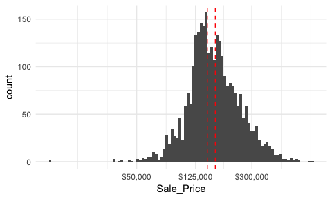

```r
ggplot(ames, aes(Sale_Price)) +
  geom_histogram(bins = 100) +
  geom_vline(xintercept = c(150000, 170000), color = "red", lty = "dashed") +
  scale_x_log10(
    labels = scales::dollar,
    breaks = c(50000, 125000, 300000)
    )
```

Let’s take a closer look at the second two insights. First, we’ll consider the issue of normality.

```r
par(mfrow = c(1, 2))
# non-log transformed
qqnorm(ames$Sale_Price, main = "Untransformed\nNormal Q-Q Plot")
qqline(ames$Sale_Price)
```

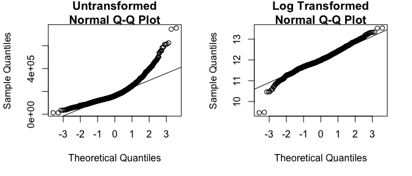

```r
# log transformed
qqnorm(log(ames$Sale_Price), main = "Log Transformed\nNormal Q-Q Plot")
qqline(log(ames$Sale_Price))
```

I also mentioned how we obtained a new insight regarding a new potential outlier that we did not see earlier. So far our histogram identified potential outliers at the lower end and upper end of the sale price spectrum. Unfortunately histograms are not very good at delineating outliers. Rather, we can use a boxplot which does a better job identifying specific outliers.

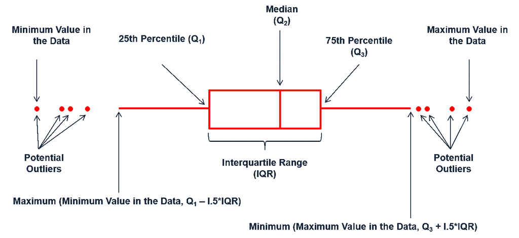

There are two efficient graphs to get an indication of potential outliers in our data. The classic boxplot on the left will identify points beyond the whiskers which are beyond $1.5*IQR$ from the first and third quantile. This illustrates there are several additional observations that we may need to assess as outliers that were not evident in our histogram. However, when looking at a boxplot we lose insight into the shape of the distribution. A violin plot on the right provides us a similar chart as the boxplot but we lose insight into the quantiles of our data and outliers are not plotted (hence the reason I plot `geom_point` prior to `geom_violin`). Violin plots will come in handy later when we start to visualize multiple distributions along side each other.

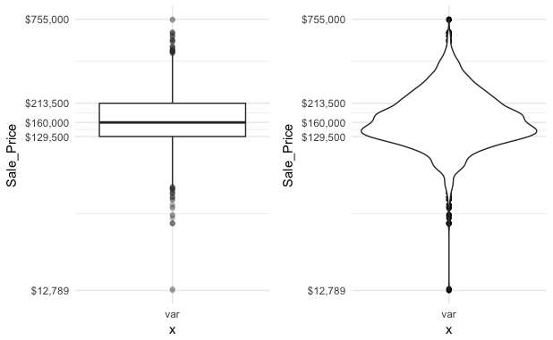

```r
p1 <- ggplot(ames, aes("var", Sale_Price)) +
  geom_boxplot(outlier.alpha = .25) +
  scale_y_log10(
    labels = scales::dollar,
    breaks = quantile(ames$Sale_Price)
  )
p2 <- ggplot(ames, aes("var", Sale_Price)) +
  geom_point() +
  geom_violin() +
  scale_y_log10(
    labels = scales::dollar,
    breaks = quantile(ames$Sale_Price)
  )
gridExtra::grid.arrange(p1, p2, ncol = 2)
```

The boxplot starts to answer the question of what potential outliers exist in your data. Outliers in data can distort predictions and affect their accuracy. Consequently, its important to understand if outliers are present and, if so, which observations are considered outliers. Boxplots provide a visual assessment of potential outliers while the `outliers` package provides a number of useful functions to systematically extract these outliers. The most useful function is the `scores` function, which computes normal, t, chi-squared, IQR and MAD scores of the given data which you can use to find observation(s) that lie beyond a given value.

Here, I use the `outliers::score` function to extract those observations beyond the whiskers in our boxplot and then use a stem and leaf plot to assess them. A stem and leaf plot is a special table where each data value is split into a “stem” (the first digit or digits) and a “leaf” (usually the second digit). Since the decimal point is located 5 digits to the right of the “|”" the last stem of “7” and and first leaf of “5” means an outlier exists at around $750,000. The last stem of “7” and and second leaf of “6” means an outlier exists at around $760,000. This is a concise way to see approximately where our outliers are. In fact, I can now see that I have 28 lower end outliers ranging from $10,000-$60,000 and 32 upper end outliers ranging from $450,000-$760,000.

```r
outliers <- outliers::scores(log(ames$Sale_Price), type = "iqr", lim = 1.5)
stem(ames$Sale_Price[outliers])
```

```
  The decimal point is 5 digit(s) to the right of the |

  0 | 1134444445555555666666666666
  1 |
  2 |
  3 |
  4 | 56666777788899
  5 | 000445566889
  6 | 1123
  7 | 56
```

Another useful plot for univariate assessment includes the *smoothed* histogram in which a non-parametric approach is used to estimate the density function. Displaying in density form just means the y-axis is now in a probability scale where the proportion of the given value (or bin of values) to the overall population is displayed. In essence, the y-axis tells you the estimated probability of the x-axis value occurring. This results in a *smoothed* curve known as the density plot that allows us visualize the distribution. Since the focus of a density plot is to view the overall distribution rather than individual bin observations we lose insight into how many observations occur at certain x values. Consequently, it can be helpful to use `geom_rug` with `geom_density` to highlight where clusters, outliers, and gaps of observations are occuring.

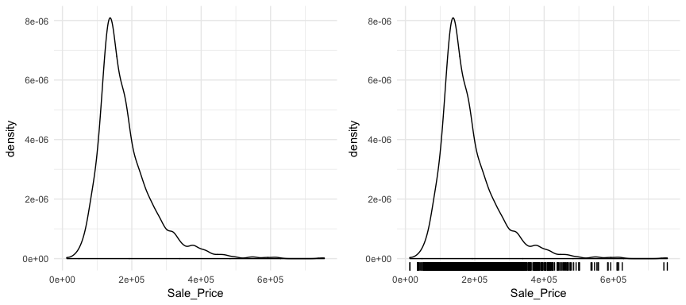

```r
p1 <- ggplot(ames, aes(Sale_Price)) +
  geom_density()
p2 <- ggplot(ames, aes(Sale_Price)) +
  geom_density() +
  geom_rug()
gridExtra::grid.arrange(p1, p2, nrow = 1)
```

Often you will see density plots layered onto histograms. To layer the density plot onto the histogram we need to first draw the histogram but tell ggplot to have the y-axis in density form rather than count. You can then add the `geom_density` function to add the density plot on top.

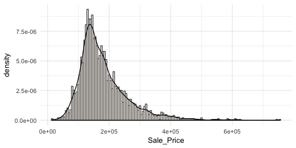

```r
ggplot(ames, aes(Sale_Price)) +
  geom_histogram(aes(y = ..density..),
                 binwidth = 5000, color = "grey30", fill = "white") +
  geom_density(alpha = .2, fill = "antiquewhite3")
```

You may also be interested to see if there are any systematic groupings with how the data is structured. For example, using base R’s `plot` function with just the `Sale_Price` will plot the sale price versus the index (row) number of each observation. In the plot below we see a pattern which indicates that groupings of homes with high versus lower sale prices are concentrated together throughout the data set.

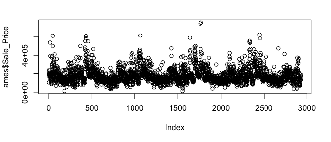

```r
plot(ames$Sale_Price)
```

There are also a couple plots that can come in handy when dealing with smaller data sets. For example, the dotplot below provides more clarity than the histogram for viewing the distribution of `mpg` in the built-in `mtcars` dataset with only 32 observations. An alternative to this would be using a strip chart (see `stripchart`).

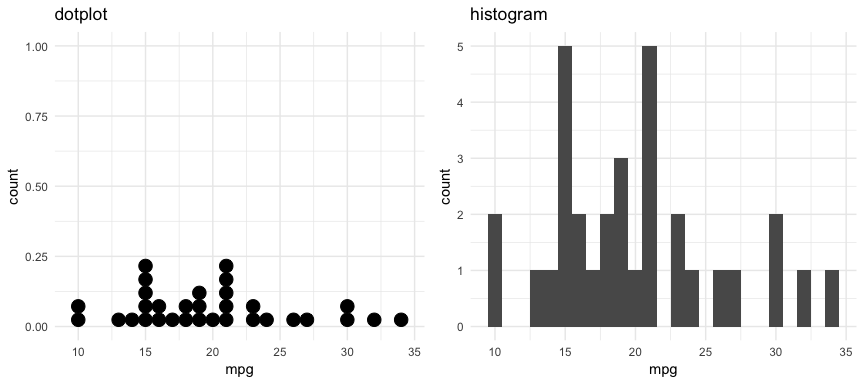

```r
p1 <- ggplot(mtcars, aes(x = mpg)) +
  geom_dotplot(method = "histodot", binwidth = 1) +
  ggtitle("dotplot")
p2 <- ggplot(mtcars, aes(x = mpg)) +
  geom_histogram(binwidth = 1) +
  ggtitle("histogram")
gridExtra::grid.arrange(p1, p2, nrow = 1)
```

As demonstrated, several plots exist for examining univariate continuous variables. Several exampes were provided here but still more exist (i.e. frequency polygon, beanplot, shifted histograms). There is some general advice to follow such as histograms being poor for small data sets, dotplots being poor for large data sets, histograms being poor for identifying outlier cut-offs, boxplots being good for outliers but obscuring multimodality. Conseqently, it is important to draw a variety of plots. Moreover, it is important to adjust parameters within plots (i.e. binwidth, axis transformation for skewed data) to get a comprehensive picture of the variable of concern.

Next, we’ll assess how we can gain insight into distributions of categorical variables.

# Visualizing Categorical Variables

A categorical variable is a variable that can take on one of a limited, and usually fixed, number of possible values, assigning each individual or other unit of observation to a particular group or nominal category on the basis of some qualitative property (i.e. gender, grade, manufacturer). There are a few different plots that can effectively communicate features of categorical variables. Features we are generally interested in include:

- Count of each category
- Proportion of each category
- Imbalanced categories
- Mislabeled categories

Bar charts are one of the most commonly used data visualizations for categorical variables. Bar charts display the levels of a categorical variable of interest (typically) along the x-axis and the length of the bar illustrates the value along the y-axis. Consequently, the length of the bar is the primary visual cue in a bar chart and in a univariate visualization this length represents counts of cases in that particular level.

If we look at the general zoning classification for each property sold in our `ames` dataset we see that the majority of all properties fall within one category. Here, `geom_bar` simply counts up all observations for each zoning level.

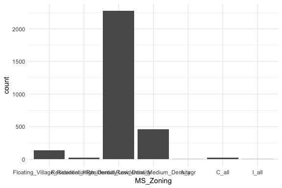

```r
ggplot(ames, aes(MS_Zoning)) +
  geom_bar()
```

Here, `MS_Zoning` represents a nominal categorical variable where there is no logical ordering of the labels; they simply represent mutually exclusive levels within our variable. To get better clarity of nominal variables we can make some refinements. Here I use `dplyr::count` to count the observations in each level prior to plotting. In the second plot I use `mutate` to compute the percent that each level makes up of all observations. I then feed these summarized data into `ggplot` where I can `reorder` the `MS_Zoning` variable from most frequent to least and then apply `coord_flip` to rotate the plot and make it easier to read the level categories. Also, notice that now I feeding an x (`MS_Zoning`) and y (`n` in the left plot and `pct` in the right plot) arguments so I apply `geom_col` rather than `geom_bar`.

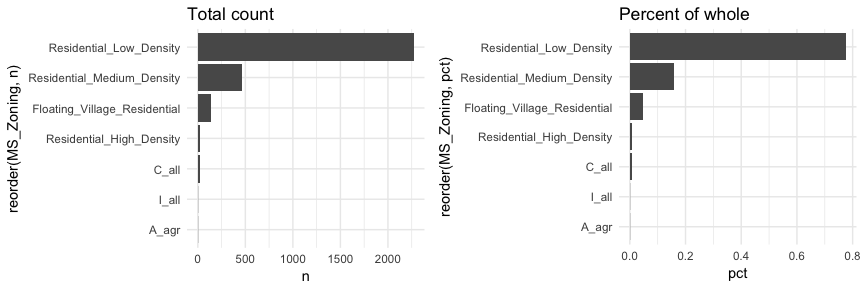

```r
# total count
p1 <- ames %>%
  count(MS_Zoning) %>%
  ggplot(aes(reorder(MS_Zoning, n), n)) +
  geom_col() +
  coord_flip() +
  ggtitle("Total count")
# percent of whole
p2 <- ames %>%
  count(MS_Zoning) %>%
  mutate(pct = n / sum(n)) %>%
  ggplot(aes(reorder(MS_Zoning, pct), pct)) +
  geom_col() +
  coord_flip() +
  ggtitle("Percent of whole")
gridExtra::grid.arrange(p1, p2, nrow = 1)
```

Now we can see that properties zoned as residential low density make up nearly 80% of all observations . We also see that properties zoned as aggricultural (`A_agr`), industrial (`I_all`), commercial (`C_all`), and residential high density make up a very small amount of observations. In fact, below we see that these imbalanced category levels each make up less than 1% of all observations.

```r
ames %>%
  count(MS_Zoning) %>%
  mutate(pct = n / sum(n)) %>%
  arrange(pct)
```

| MS_Zoning | n | pct |
| --- | --- | --- |
| A_agr | 2 | 0.0006825939 |
| I_all | 2 | 0.0006825939 |
| C_all | 25 | 0.0085324232 |
| Residential_High_Density | 27 | 0.0092150171 |
| Floating_Village_Residential | 139 | 0.0474402730 |
| Residential_Medium_Density | 462 | 0.1576791809 |
| Residential_Low_Density | 2273 | 0.7757679181 |

This imbalanced nature can cause problems in future analytic models so it may make sense to combine these infrequent levels into an “other” category. An easy way to do that is to use `fct_lump`.[^4] Here we use `n = 2` to retain the top 2 levels in our variable and condense the remaining into an “other” category. You can see that this combined category still represents less than 10% of all observations.

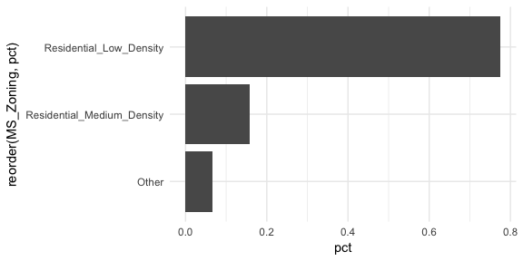

```r
ames %>%
  mutate(MS_Zoning = fct_lump(MS_Zoning, n = 2)) %>%
  count(MS_Zoning) %>%
  mutate(pct = n / sum(n)) %>%
  ggplot(aes(reorder(MS_Zoning, pct), pct)) +
  geom_col() +
  coord_flip()
```

Basic bar charts such as these are great when the number of category levels is smaller. However, as the number of levels increase the thick nature of the bar can be distracting. Cleveland dot plots and lollipop charts are useful for assessing the frequency or proportion of many levels while minizing the amount of ink on the graphic.